# Human Activity Pattern Recognition and Quality prediction with Random Forest Algorithm

Abiyu Giday

November 22, 2015

# Motivation:

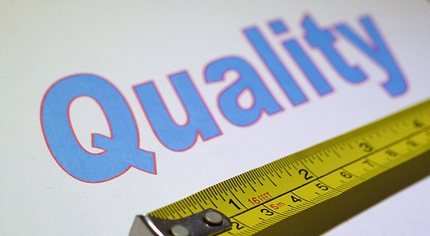

When it comes to human physical activity, quantifying repetition of a particular exercise is easier than measuring quality or how well the exercise is performed. Paying attention to both frequency and quality will result in optimal outcome. However, measuring quality of physical activity is a subtle but important aspect that differs from one individual to the other. Here we will discuss how Machine Learning (ML) algorithm model is utilized to recognize exercise patterns and predict the quality in which the exercise is performed. The preclassified training dataset is used to generate a machine learning model. The dataset contains data on six volunteers that performed a dumbbell weight lifting exercise with 5 levels of quality ranges (labled A-E in the trianing data set - not labled on test dataset). The specifics of the exercise is detailed in the next section labled ‘The Experiment’. Few ML algorithms were considered before selecting the Random Forest (RF) algorithm which resulted in 98% level of accuracy.

[CaretPackage](http://topepo.github.io/caret/index.html) is used, to preprocess, train and tune the model on the human [activity recognition dataset](https://d396qusza40orc.cloudfront.net/predmachlearn/pml-training.csv). Principal Component Analysis (PCA) function was used in the preprocessing stage to separate the signal from the noise and select optimal features based on finding new set of multivariate variables that represent as much of the variability. As we will see, PCA needed 25 features (out of 53) to capture 95% of the variance. Because the row dataset contains 19,622 observations and 160 features, a fairly large data size for personal computers single core processor, the [‘doMC’ package](https://cran.r-project.org/web/packages/doMC/doMC.pdf) was used to make 8 core processors available to digest the data in parallel, cutting down the amount of time it took to train the Random Forest algorithm from 3+ hours to less than 10 minutes.

This document is follows redproducible research principles in which the markdown file download the the data directly from the source, tidy the data, run random forest algorithm and plot the figures dynamically.

# The Experiment:

Here is an excerpt from the paper written to describe the experiment:

“*This human activity recognition research has traditionally focused on discriminating between different activities, i.e. to predict “which” activity was performed at a specific point in time (like with the Daily Living Activities dataset above). The approach we propose for the Weight Lifting Exercises dataset is to investigate “how (well)” an activity was performed by the wearer. The “how (well)” investigation has only received little attention so far, even though it potentially provides useful information for a large variety of applications,such as sports training.*

*In this work (see the paper) we first define quality of execution and investigate three aspects that pertain to qualitative activity recognition: the problem of specifying correct execution, the automatic and robust detection of execution mistakes, and how to provide feedback on the quality of execution to the user. We tried out an on-body sensing approach (dataset here), but also an “ambient sensing approach” (by using Microsoft Kinect - dataset still unavailable)*

*Six young health participants were asked to perform one set of 10 repetitions of the Unilateral Dumbbell Biceps Curl in five different fashions: exactly according to the specification (Class A), throwing the elbows to the front (Class B), lifting the dumbbell only halfway (Class C), lowering the dumbbell only halfway (Class D) and throwing the hips to the front (Class E).*"

# Machine Learning Steps

The following steps detail the data collection and exploration, followed by how parallel computing and how it was configured and used to minimize the amount to time it took to process the dataset. We then discuss the steps to train, tune and evaluate the dataset.

## Data Collection:

```r
library(dplyr)
library(caret)
library(randomForest)
library(rattle)
library(pROC)
library(foreach)
library(doMC)
registerDoMC(cores = 8)


#Download training data
if(!file.exists("./data")){dir.create("./data")}
fileUrl <- "https://d396qusza40orc.cloudfront.net/predmachlearn/pml-training.csv"
download.file(fileUrl, destfile = "./data/pml-training.csv", method = "curl")

trainData <- read.csv("./data/pml-training.csv")

#Structure of the dataset
#str(trainData)
#names(trainData)

#Download test data
if(!file.exists("./data")){dir.create("./data")}
fileUrl <- "https://d396qusza40orc.cloudfront.net/predmachlearn/pml-testing.csv"
download.file(fileUrl, destfile = "./data/pml-testing.csv", method = "curl")

testData <- read.csv("./data/pml-testing.csv")
```

Here are all of the features in the dataset. Notice the quality measurment for each person is listed in the *classe* feature of the training dataset.

```r
names(trainData)
```

```
##   [1] "X"                        "user_name"
##   [3] "raw_timestamp_part_1"     "raw_timestamp_part_2"
##   [5] "cvtd_timestamp"           "new_window"
##   [7] "num_window"               "roll_belt"
##   [9] "pitch_belt"               "yaw_belt"
##  [11] "total_accel_belt"         "kurtosis_roll_belt"
##  [13] "kurtosis_picth_belt"      "kurtosis_yaw_belt"
##  [15] "skewness_roll_belt"       "skewness_roll_belt.1"
##  [17] "skewness_yaw_belt"        "max_roll_belt"
##  [19] "max_picth_belt"           "max_yaw_belt"
##  [21] "min_roll_belt"            "min_pitch_belt"
##  [23] "min_yaw_belt"             "amplitude_roll_belt"
##  [25] "amplitude_pitch_belt"     "amplitude_yaw_belt"
##  [27] "var_total_accel_belt"     "avg_roll_belt"
##  [29] "stddev_roll_belt"         "var_roll_belt"
```

[output cut: 65 more lines]

## Data Exploration:

In the following steps we will tidy the data with dplyr package. Variables not used as measurment and contain only missing values are removed resulting in just 53 features out of 160.

```r
#Remove variables that contain only NA
library(dplyr)
df1 <- trainData
df2 <- df1 %>% select(-matches("^kurtosis|^skewness|^max|^min|^amplitude|^var|^stddev|^avg"))

#Remove variables that do not measure performance & reorder data table with classe feature appearing on column 1
df3 <- df2[,-c(1:7)]
df3 <- df3[, c(53,1:52)]

# Structur of the new dataset
str(df3)
```

```
## 'data.frame':    19622 obs. of  53 variables:
##  $ classe              : Factor w/ 5 levels "A","B","C","D",..: 1 1 1 1 1 1 1 1 1 1 ...
##  $ roll_belt           : num  1.41 1.41 1.42 1.48 1.48 1.45 1.42 1.42 1.43 1.45 ...
##  $ pitch_belt          : num  8.07 8.07 8.07 8.05 8.07 8.06 8.09 8.13 8.16 8.17 ...
##  $ yaw_belt            : num  -94.4 -94.4 -94.4 -94.4 -94.4 -94.4 -94.4 -94.4 -94.4 -94.4 ...
##  $ total_accel_belt    : int  3 3 3 3 3 3 3 3 3 3 ...
##  $ gyros_belt_x        : num  0 0.02 0 0.02 0.02 0.02 0.02 0.02 0.02 0.03 ...
##  $ gyros_belt_y        : num  0 0 0 0 0.02 0 0 0 0 0 ...
##  $ gyros_belt_z        : num  -0.02 -0.02 -0.02 -0.03 -0.02 -0.02 -0.02 -0.02 -0.02 0 ...
##  $ accel_belt_x        : int  -21 -22 -20 -22 -21 -21 -22 -22 -20 -21 ...
##  $ accel_belt_y        : int  4 4 5 3 2 4 3 4 2 4 ...
##  $ accel_belt_z        : int  22 22 23 21 24 21 21 21 24 22 ...
##  $ magnet_belt_x       : int  -3 -7 -2 -6 -6 0 -4 -2 1 -3 ...
##  $ magnet_belt_y       : int  599 608 600 604 600 603 599 603 602 609 ...
##  $ magnet_belt_z       : int  -313 -311 -305 -310 -302 -312 -311 -313 -312 -308 ...
```

[output cut: 39 more lines]

```r
#Verify if missing values are in the dataset
sum(is.na(df2))
```

```
## [1] 0
```

## Parallel Computing:

Here we set the number of cores for parallel computing to 8. This is enabled with the ‘doMC’ packages and setting the cores to 8( eight because the mahcine used have 8 cores available to it.) . Being able to parallely train the data cut the amount of time significantly.

```r
#Register the number of cores to be used.
library(doMC)
registerDoMC(cores = 8)
```

## Spliting the data into training and validation:

The training data is split using the createDataParition function from the caret package. The split was 75/25. 75% is set aside to train the model, and 25% was set aside to validate the trained model.

```r
library(caret)
#Split the training data into training and validation
set.seed(1582)
inTrain <- createDataPartition(y = df3$classe, p = 0.75, list = FALSE)
train22 <- df3[inTrain,]
valdt22 <- df3[-inTrain,]

#check if missing value exist
dim(train22)
```

```
## [1] 14718    53
```

```r
sum(is.na(train22))
```

```
## [1] 0
```

```r
dim(valdt22)
```

```
## [1] 4904   53
```

```r
sum(is.na(valdt22))
```

```
## [1] 0
```

```r
#PreProcessing
```

## Tuning and training the Model

On personal computer’s (PC), it takes fairly long time to train the data with 20 thousand observation, especially when number of folds or number of resampling iteration is set to higher number. On this case number of resmpling is left to a default (10 repeat is commented out in the configuration because even with 8 cores, 10 repetion took over three hours to process). To train the model, Random Forest (rf) machine learning algorithm is used, and Principal Component Analysis (PCA) is turned on for preprocessing, centering and scaling of the data is also excplicityly set to scale and center the data during preprocessing stage. The *system.time* function is configured to measure the proceesing duration.

```r
fitControl <- trainControl(
        method = "repeatedcv",
        #number = 10,
        #repeats = 10,
        allowParallel = TRUE)

set.seed(222)
system.time(modFit1 <- train(classe ~.,
                             data = train22,
                             method = "rf",
                             preProcess=c("pca","center","scale"),
                             trControl=fitControl))
```

```
##     user   system  elapsed
## 1152.928   14.152  209.928
```

### Plots for the model

The following set of plots show Model vs Accuracy and Accuracy and kappa normal curves respectively.

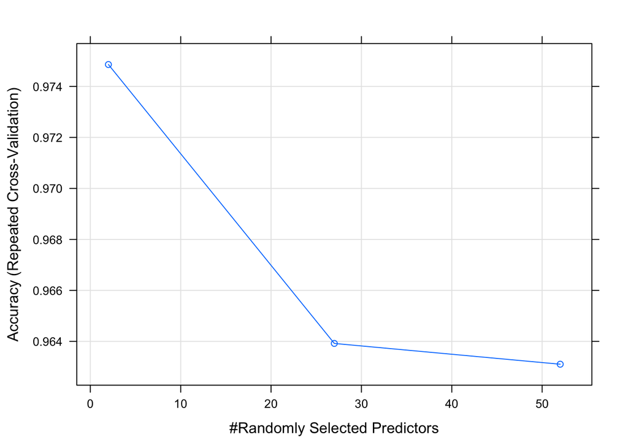

```r
plot(modFit1)
```

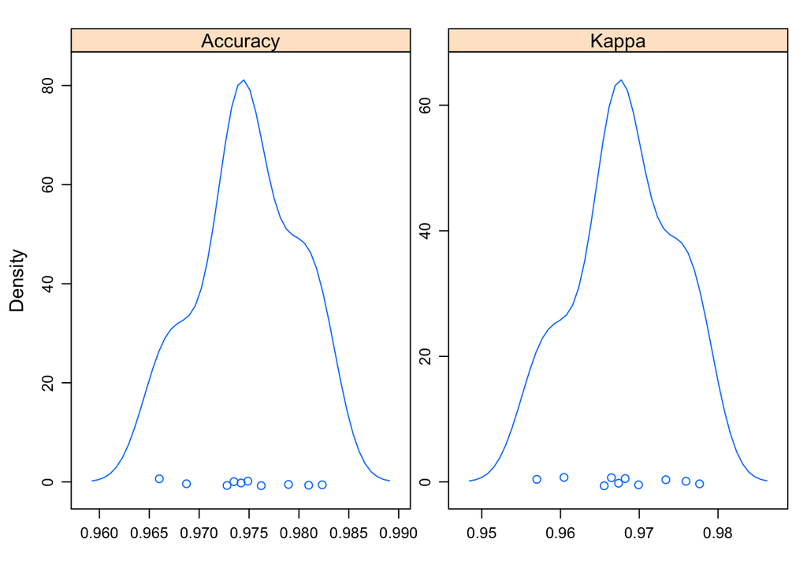

```r
resampleHist(modFit1) #
```

### Variable Importance

Of the 53 variables used in the training data, preprocessing with PCA identfied **25 predictors that can explain 95%** of the variance. The follwoing steps reveal important features.

```r
modFit1$preProcess
```

```
## Created from 14718 samples and 52 variables
##
## Pre-processing:
##   - centered (52)
##   - ignored (0)
##   - principal component signal extraction (52)
##   - scaled (52)
##
## PCA needed 25 components to capture 95 percent of the variance
```

```r
varImp(modFit1)
```

```
## rf variable importance
##
##   only 20 most important variables shown (out of 25)
##
##      Overall
## PC8   100.00
## PC14   96.89
## PC12   90.66
## PC1    88.69
## PC5    72.30
## PC3    69.42
## PC15   66.35
## PC9    62.69
## PC6    61.13
## PC2    59.73
## PC7    49.27
## PC16   48.58
## PC22   47.00
## PC17   45.48
## PC4    41.69
## PC13   41.04
## PC10   40.64
## PC25   40.08
## PC21   39.85
## PC20   35.80
```

#### Variable importance plot

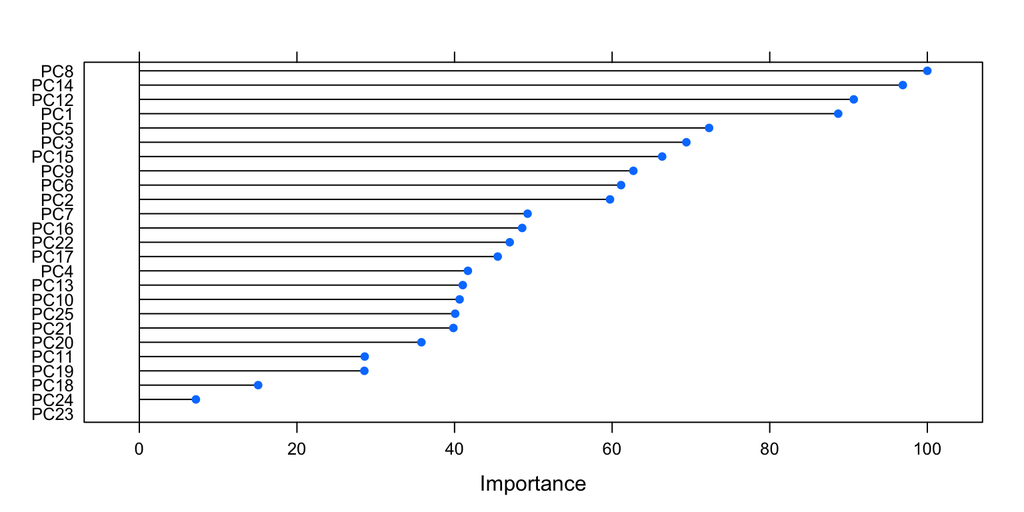

Var Importance Plot

```r
plot(varImp(modFit1))
```

#### Scatter plot for selected important variables

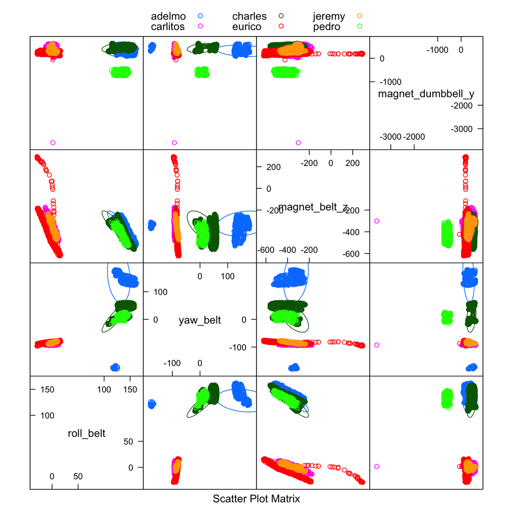

Scatterplot Matrix with Ellipses

```r
# Scatterplot Matrix with Ellipses
featurePlot(x = df2[, c(8,10,20,45)],
            y = df2$user_name,
            plot = "ellipse",
            ## Add a key at the top
            auto.key = list(columns = 3))
```

# Model Evaluation:

```r
modFit1$finalModel
```

```
##
## Call:
##  randomForest(x = x, y = y, mtry = param$mtry)
##                Type of random forest: classification
##                      Number of trees: 500
## No. of variables tried at each split: 2
##
##         OOB estimate of  error rate: 2.28%
## Confusion matrix:
##      A    B    C    D    E class.error
## A 4159   10   11    3    2 0.006212664
## B   46 2766   29    2    5 0.028792135
## C    2   31 2506   27    1 0.023763148
## D    5    2  103 2297    5 0.047678275
## E    1   15   17   18 2655 0.018847007
```

```r
confusionMatrix(valdt22$classe,predict(modFit1,valdt22))
```

```
## Confusion Matrix and Statistics
##
##           Reference
## Prediction    A    B    C    D    E
##          A 1390    1    1    2    1
##          B   21  918    9    0    1
##          C    1   18  828    7    1
##          D    1    1   39  761    2
##          E    0    0    5    4  892
##
## Overall Statistics
##
##                Accuracy : 0.9765
##                  95% CI : (0.9719, 0.9806)
##     No Information Rate : 0.2881
##     P-Value [Acc > NIR] : < 2.2e-16
##
##                   Kappa : 0.9703
##  Mcnemar's Test P-Value : 2.548e-07
##
## Statistics by Class:
##
##                      Class: A Class: B Class: C Class: D Class: E
## Sensitivity            0.9837   0.9787   0.9388   0.9832   0.9944
## Specificity            0.9986   0.9922   0.9933   0.9896   0.9978
## Pos Pred Value         0.9964   0.9673   0.9684   0.9465   0.9900
## Neg Pred Value         0.9934   0.9949   0.9867   0.9968   0.9988
## Prevalence             0.2881   0.1913   0.1799   0.1578   0.1829
## Detection Rate         0.2834   0.1872   0.1688   0.1552   0.1819
## Detection Prevalence   0.2845   0.1935   0.1743   0.1639   0.1837
## Balanced Accuracy      0.9911   0.9854   0.9660   0.9864   0.9961
```

```r
# area under the ROC curve for each predictor
RocImportance <- filterVarImp(x=train22[,-ncol(train22)], y = train22$classe)
head(RocImportance)
```

```
##                          A         B         C         D         E
## classe           1.0000000 1.0000000 1.0000000 1.0000000 1.0000000
## roll_belt        0.6391397 0.6214129 0.6276103 0.6434238 0.6434238
## pitch_belt       0.5432035 0.5268634 0.5390042 0.5448612 0.5448612
## yaw_belt         0.5625353 0.5601188 0.5546821 0.5492554 0.5625353
## total_accel_belt 0.5680607 0.5385448 0.5279744 0.5435384 0.5680607
## gyros_belt_x     0.5291272 0.5291272 0.5107615 0.5099477 0.5107700
```

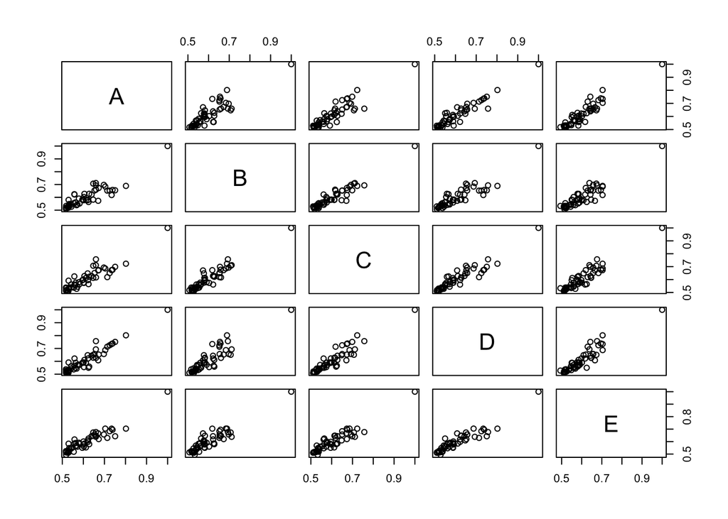

```r
plot(RocImportance)
```

```r
#Testing the model against the testData
data.frame(TestData = testData$user_name, Predicted = predict(modFit1, testData))
```

```
##    TestData Predicted
## 1     pedro         B
## 2    jeremy         A
## 3    jeremy         C
## 4    adelmo         A
## 5    eurico         A
## 6    jeremy         E
## 7    jeremy         D
## 8    jeremy         B
## 9  carlitos         A
## 10  charles         A
## 11 carlitos         A
## 12   jeremy         C
## 13   eurico         B
## 14   jeremy         A
## 15   jeremy         E
## 16   eurico         E
## 17    pedro         A
## 18 carlitos         B
## 19    pedro         B
## 20   eurico         B
```

# Take Away:

The objective of this exercise had been to create a model that will accurately recognize patterns and predict the manner (quality) in which the participants of the experiment exercised from the collected dataset. Utilizing the Random Forest algorithm, a model was generated with Caret packages function, and preprocessed with PCA to select optimal number of high valued variables resulting in a a very high level of pattern recognition and accuracy.

# Reference

_Ugulino, W.; Cardador, D.; Vega, K.; Velloso, E.; Milidiu, R.; Fuks, H. Wearable Computing: Accelerometers’ Data Classification of Body Postures and Movements Read more: http://groupware.les.inf.puc-rio.br/har#ixzz3sEPIq2gc_

_Velloso, E.; Bulling, A.; Gellersen, H.; Ugulino, W.; Fuks, H. Qualitative Activity Recognition of Weight Lifting Exercises. Proceedings of 4th International Conference in Cooperation with SIGCHI (Augmented Human ’13) . Stuttgart, Germany: ACM SIGCHI, 2013. Read more: http://groupware.les.inf.puc-rio.br/har#wle_paper_section#ixzz3sGJpMNZm_

_Max Kuhn. PhD Pfizer Global R&D, http://topepo.github.io/caret/index.html_

_Jeff Leek, PhD - Practical Machine Learning lectures. https://www.coursera.org/course/predmachlearn_

_Wikepedia: https://en.wikipedia.org/wiki/Machine_learning_

_StackOverflow: http://stackoverflow.com/_